# explanatory_results slides

## Investigation Overview

In this investigation, I wanted to look at the PISA (Programme for International Student Assessment) 2012 test scores and examine Gender difference as well as differences amongst countries that are part of the OECD and countries that are not a part of the OECD.

In addition, I also wanted to look at the relationship between the Learning Time in Minutes for 3 subjects (Math, Reading and Science) and determine if I could establish a quick predictive model for the student's test grade. Although the findings in this section were initially promising when aggregating the data, the findings in this section were inconclusive on a country to country basis and the author suggests further investigating to reliably determine the relationships.

## Data Overview

The data consisted of 480,000 rows and 635 columns. Each row represented a different student surveyed and each column represented an answer in the survey questionaire. The important columns were the ones designating

1. The country
2. The student's gender.
3. The country's inclusion in the OECD
4. The student's test scores in:
   - Math
   - Reading
   - Science
5. The learning time in minutes/week for
   - Math
   - Reading
   - Science

## The amount of countries, their inclusion in the OECD and the gender distribution

In total there were 65 different countries and 3 extra states within the United States of America that were investigated for a total of 68 regions/countries.

34 regions were part of the OECD and 34 regions were not part of the OECD

Each country had at least 1,500 respondents besides Liechtenstein which only had 293. The country with the most respondents was Mexico with 33806. The 3 countries with the most and the 3 countries with the least respondants are represented in a table below.

The male to female was ratio was 1:1 with approximately 240,000 males surveyed and 245,000 females surveyed.

```python
countries_oecd= pisa_sub[['CNT','OECD']]
countries_oecd.drop_duplicates(inplace=True)
countries_oecd = countries_oecd.groupby('OECD').size().reset_index(name='count')
countries_oecd.rename(columns={'OECD':'Country designation'})
```

|  | Country designation | count |
| --- | --- | --- |
| 0 | Non-OECD | 34 |
| 1 | OECD | 34 |

```python
countries_size = pisa_sub.groupby('CNT').size().reset_index(name='number of respondants')
countries_size.sort_values(by='number of respondants', ascending=False, inplace=True)
top_3_bottom_3 = countries_size.head(3).index
top_3_bottom_3 = top_3_bottom_3.append(countries_size.tail(3).index)

countries_size.loc[top_3_bottom_3].reset_index(drop=True)
```

|  | CNT | number of respondants |
| --- | --- | --- |
| 0 | Mexico | 33806 |
| 1 | Italy | 31073 |
| 2 | Spain | 25313 |
| 3 | Massachusetts (USA) | 1723 |
| 4 | Connecticut (USA) | 1697 |
| 5 | Liechtenstein | 293 |

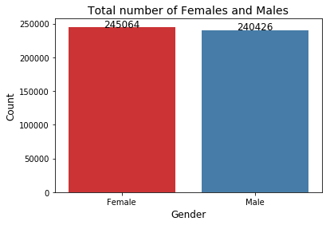

```python
genders = pisa_sub.Gender.value_counts().reset_index(name='counts')
ax = sb.barplot(data=genders, x=genders['index'], y =genders.counts, palette='Set1')
plt.title('Total number of Females and Males', fontsize = 14)
plt.xlabel('Gender', fontsize= 12)
plt.ylabel('Count', fontsize = 12)
for count in ax.patches:
    height= count.get_height()
    ax.text(count.get_x() + count.get_width()/2, height + 3, '{:.0f}'.format(height), ha='center', fontsize=12)
```

## Distribution of Test Scores

Test scores were seperated in each subject: Math, Reading and Science. The lowest score recorded was a 0 while the highest score was a 962.

The test score distribution can be found below.

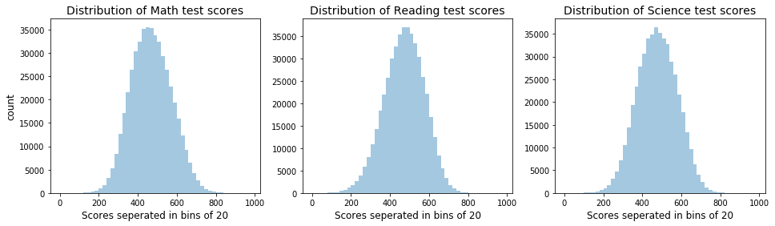

```python
interval = 20
bin_edges=np.arange(0, pisa_sub.PV1MATH.max()+interval, interval)
fig = plt.figure(figsize=(16, 4))


plt.subplot(1,3,1);
sb.distplot(pisa_sub['PV1MATH'], kde=False, bins=bin_edges);
plt.ylabel('count', fontsize= 12);
plt.title('Distribution of Math test scores', fontsize= 14)
plt.xlabel('Scores seperated in bins of 20', fontsize= 12);

plt.subplot(1,3,2);
sb.distplot(pisa_sub['PV1READ'], kde=False, bins=bin_edges);
plt.title('Distribution of Reading test scores', fontsize= 14)
plt.xlabel('Scores seperated in bins of 20', fontsize= 12);

plt.subplot(1,3,3);
sb.distplot(pisa_sub['PV1SCIE'], kde=False, bins=bin_edges);
plt.title('Distribution of Science test scores', fontsize= 14);
plt.xlabel('Scores seperated in bins of 20', fontsize= 12);
```

```python
stats = pisa_sub[['PV1MATH','PV1READ','PV1SCIE']].describe().round(2)
stats.rename(columns={'PV1MATH':'Math test scores','PV1READ':'Reading test scores','PV1SCIE':'Science test scores'},inplace=True)

stats
```

|  | Math test scores | Reading test scores | Science test scores |
| --- | --- | --- | --- |
| count | 485490.00 | 485490.00 | 485490.00 |
| mean | 469.62 | 472.00 | 475.77 |
| std | 103.27 | 102.51 | 101.46 |
| min | 19.79 | 0.08 | 2.65 |
| 25% | 395.32 | 403.60 | 404.46 |
| 50% | 466.20 | 475.46 | 475.70 |
| 75% | 541.06 | 544.50 | 547.78 |
| max | 962.23 | 904.80 | 903.34 |

## Distribution of Learning Time in minutes per week

The majority of the respondants spend less then 500 minutes per subject per week

```
<function matplotlib.pyplot.tight_layout(pad=1.08, h_pad=None, w_pad=None, rect=None)>
```

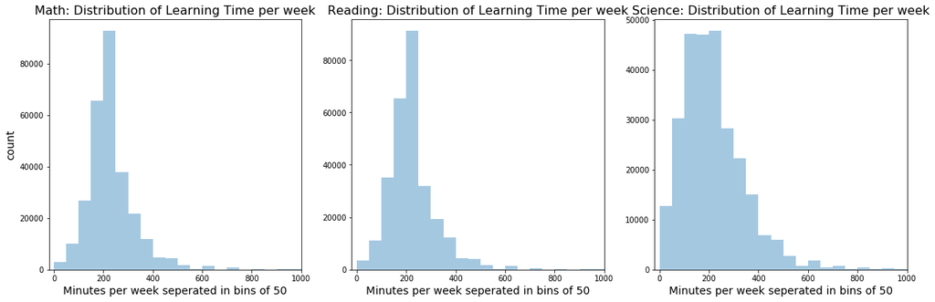

```python
interval = 50
bin_edges=np.arange(0, pisa_sub.MMINS.max()+interval, interval)
fig = plt.figure(figsize=(20, 6))
threshold = 1000

plt.subplot(1,3,1);
sb.distplot(pisa_sub.MMINS, kde=False, bins=bin_edges);
plt.xlim(-20,threshold);
plt.ylabel('count', fontsize=14);
plt.xlabel('Minutes per week seperated in bins of ' + str(interval), fontsize= 14);
plt.title('Math: Distribution of Learning Time per week', fontsize= 16)

plt.subplot(1,3,2);
sb.distplot(pisa_sub.LMINS, kde=False, bins=bin_edges);
plt.xlim(-20,threshold);
plt.xlabel('Minutes per week seperated in bins of ' + str(interval), fontsize= 14);
plt.title('Reading: Distribution of Learning Time per week', fontsize= 16);

plt.subplot(1,3,3);
sb.distplot(pisa_sub.SMINS, kde=False, bins=bin_edges);
plt.xlim(-20,threshold);
plt.xlabel('Minutes per week seperated in bins of ' + str(interval), fontsize= 14);
plt.title('Science: Distribution of Learning Time per week', fontsize= 16);

plt.tight_layout
```

## Test results by country

I've decided to showcase the top 3 and bottom 3 countries in terms of Test performance in each subject (Math, Reading and Science).

The Genders are also showcased in each selected country.

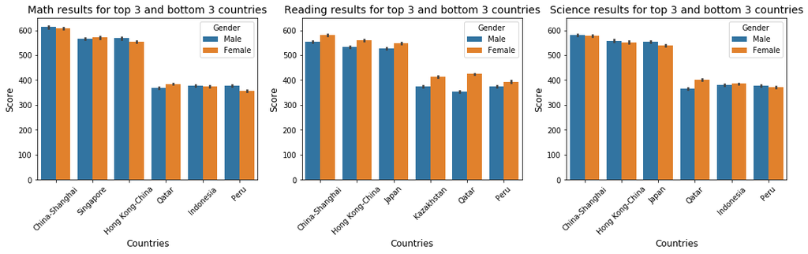

```python
subjects={'Math':{'index1':math_top_bottom_3, 'test_code':'PV1MATH'},'Reading':{'index1':reading_top_bottom_3,'test_code':'PV1READ'},'Science':{'index1':science_top_bottom_3,'test_code':'PV1SCIE'}};

fig = plt.figure(figsize=(18, 4));

i=1
for subject in subjects:
    plt.subplot(1,3,i);
    sub_group=pisa_sub[pisa_sub.CNT.isin(subjects[subject]['index1'])];
    sb.barplot(data= sub_group, x=sub_group.CNT, y=sub_group[subjects[subject]['test_code']], hue='Gender', order=subjects[subject]['index1']);
    plt.xticks(rotation=45);
    plt.ylim(0,650);
    plt.title(str(subject) + ' results for top 3 and bottom 3 countries', fontsize=14);
    plt.ylabel('Score', fontsize=12);
    plt.xlabel('Countries', fontsize=12);
    i=i+1
```

## Test results by OECD vs Non-OECD countries along with Gender Segregations

In the Math category, for the OECD countries, we can notice a small gender difference in the mean and 3rd quartile in the favor of males. The same difference can be observed in the Science Test scores. This means that in OECD countries, males who perform really well slightly outperform the high achieving females.

In the Reading section, we can notice a significant difference in both categories, OECD vs Non-OECD country and Females vs Males. OECD countries score significantly higher then their non-OECD counterparts and Females score significantly higher then their male counterparts in both regions (OECD and non-OECD). Females in the OECD category at the 1st quartile (25%) would belong in the 50th percentile in Non-OECD countries, this is a major difference.

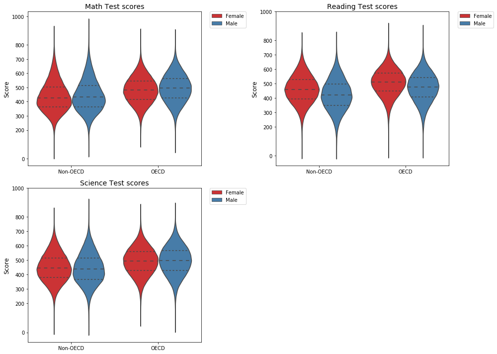

```python
plt.figure(figsize = [14, 10]);

plots={'Math':'PV1MATH','Reading':'PV1READ','Science':'PV1SCIE'}

i=1
for subject in plots:
    plt.subplot(2,2,i)
    sb.violinplot(data=pisa_sub, x='OECD', y=plots[subject], inner='quartile', hue='Gender', palette='Set1')
    plt.legend(bbox_to_anchor=(1.05, 1), loc=2, borderaxespad=0.)
    plt.yticks(ticks=[0,200,300,400,500,600,700,800,1000])
    plt.ylabel('Score', fontsize= 12)
    plt.xlabel('')
    plt.title(subject+' Test scores', fontsize= 14)
    i=i+1

plt.tight_layout()
```

## Establishing the relationship between Learning Time in minutes per week and Test Scores

When using the whole dataset, there appears to be a weak positive correlation between the Learning Time in minutes per week and test scores.

The respective scatter plots and heatmaps have been drawn out for all 3 subjects below.

The strongest correlation can be found in with the Science test scores

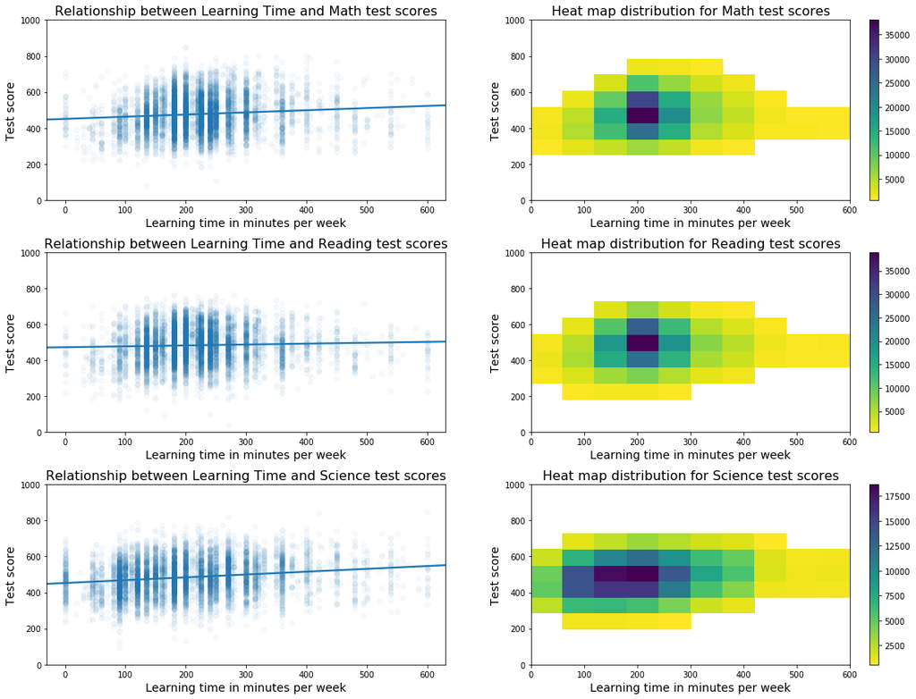

```python
plt.figure(figsize = [16, 12]);

plt.subplot(3,2,1)
sb.regplot(data=pisa_sub.query('MMINS<=600').sample(7000), x='MMINS', y='PV1MATH', scatter_kws ={'alpha':1/30}, ci=None)
plt.title('Relationship between Learning Time and Math test scores', fontsize = 16)
plt.xlabel('Learning time in minutes per week', fontsize= 14)
plt.ylabel('Test score', fontsize= 14)
plt.ylim(0,1000)

plt.subplot(3,2,2)
plt.hist2d(data=pisa_sub.query('MMINS<=600'), x='MMINS', y='PV1MATH', cmin=500, cmap='viridis_r');
plt.colorbar()
plt.xlabel('Learning time in minutes per week', fontsize= 14)
plt.title('Heat map distribution for Math test scores', fontsize = 16)
plt.ylabel('Test score', fontsize= 14)
plt.ylim(0,1000)

plt.subplot(3,2,3)
sb.regplot(data=pisa_sub.query('LMINS<=600').sample(7000), x='LMINS', y='PV1READ', scatter_kws ={'alpha':1/30}, ci=None)
plt.title('Relationship between Learning Time and Reading test scores', fontsize = 16)
plt.xlabel('Learning time in minutes per week', fontsize= 14)
plt.ylabel('Test score', fontsize= 14)
plt.ylim(0,1000)

plt.subplot(3,2,4)
plt.hist2d(data=pisa_sub.query('LMINS<=600'), x='LMINS', y='PV1READ', cmin=500, cmap='viridis_r');
plt.colorbar()
plt.xlabel('Learning time in minutes per week', fontsize= 14)
plt.title('Heat map distribution for Reading test scores', fontsize = 16)
plt.ylabel('Test score', fontsize= 14)
plt.ylim(0,1000)

plt.subplot(3,2,5)
sb.regplot(data=pisa_sub.query('SMINS<=600').sample(7000), x='SMINS', y='PV1SCIE', scatter_kws ={'alpha':1/30}, ci=None)
plt.title('Relationship between Learning Time and Science test scores', fontsize = 16)
plt.xlabel('Learning time in minutes per week', fontsize= 14)
plt.ylabel('Test score', fontsize= 14)
plt.ylim(0,1000)

plt.subplot(3,2,6)
plt.hist2d(data=pisa_sub.query('SMINS<=600'), x='SMINS', y='PV1SCIE', cmin=500, cmap='viridis_r');
plt.colorbar()
plt.xlabel('Learning time in minutes per week', fontsize= 14)
plt.title('Heat map distribution for Science test scores', fontsize = 16)
plt.ylabel('Test score', fontsize= 14)
plt.ylim(0,1000)

plt.tight_layout()
```

```python
#dictionary with all the pair values
topics={'Math':{'Minutes':'MMINS','test_code':'PV1MATH'},'Reading':{'Minutes':'LMINS','test_code':'PV1READ'},'Science':{'Minutes':'SMINS','test_code':'PV1SCIE'} }


results= pd.DataFrame(columns=['Subject','pearsonR','p-value'])

#this part loops through the topics dictionary to get the pearson R coefficient and the p-value for the 3 pairs in topics.
for subject in topics:
    copy=pisa_sub.copy()
    copy=copy.dropna(subset=[topics[subject]['Minutes']])   #this line drops all the lines that do not contain any values
    pearsonr, pvalue = scipy.stats.pearsonr(copy[topics[subject]['Minutes']], copy[topics[subject]['test_code']])
    results.at[subject,'Subject']  = subject
    results.at[subject,'pearsonR'] = pearsonr.round(3)
    results.at[subject,'p-value']  = pvalue.round(3)



results.reset_index(drop=True,inplace=True)

results
```

|  | Subject | pearsonR | p-value |
| --- | --- | --- | --- |
| 0 | Math | 0.069 | 0 |
| 1 | Reading | 0.029 | 0 |
| 2 | Science | 0.144 | 0 |

## An interesting area of research for future studies: Learning time per minutes and Test Scores on a country by country basis

Since it is expected that Test results would increase as students spend more time learning, the author of this investigation suggests further investigations to reliably determine the relationships.

A few examples are shown below.

```
(0, 600)
```

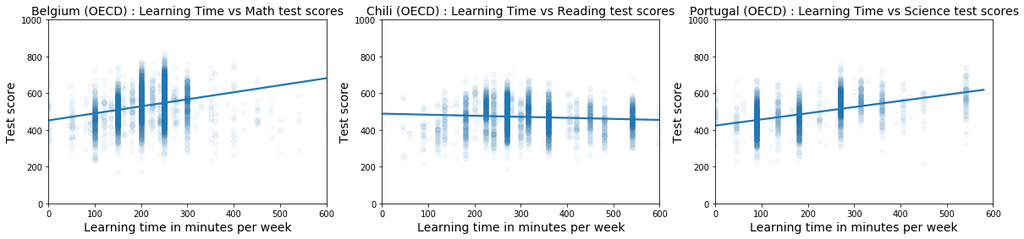

```python
plt.figure(figsize = [20, 4]);

plt.subplot(1,3,1)
sb.regplot(data=pisa_sub.query('CNT=="Belgium" and MMINS<=600'), x='MMINS', y='PV1MATH', scatter_kws ={'alpha':1/30}, ci=None)
plt.title('Belgium (OECD) : Learning Time vs Math test scores', fontsize=14)
plt.xlabel('Learning time in minutes per week', fontsize=14)
plt.ylabel('Test score', fontsize=14)
plt.ylim(0,1000)
plt.xlim(0,600)

plt.subplot(1,3,2)
sb.regplot(data=pisa_sub.query('CNT=="Chile" and LMINS<=600'), x='LMINS', y='PV1READ', scatter_kws ={'alpha':1/30}, ci=None)
plt.title('Chili (OECD) : Learning Time vs Reading test scores', fontsize=14)
plt.xlabel('Learning time in minutes per week', fontsize=14)
plt.ylabel('Test score', fontsize=14)
plt.ylim(0,1000)
plt.xlim(0,600)

plt.subplot(1,3,3)
sb.regplot(data=pisa_sub.query('CNT=="Portugal" and SMINS<=600'), x='SMINS', y='PV1SCIE', scatter_kws ={'alpha':1/30}, ci=None)
plt.title('Portugal (OECD) : Learning Time vs Science test scores', fontsize=14)
plt.xlabel('Learning time in minutes per week', fontsize=14)
plt.ylabel('Test score', fontsize=14)
plt.ylim(0,1000)
plt.xlim(0,600)
```

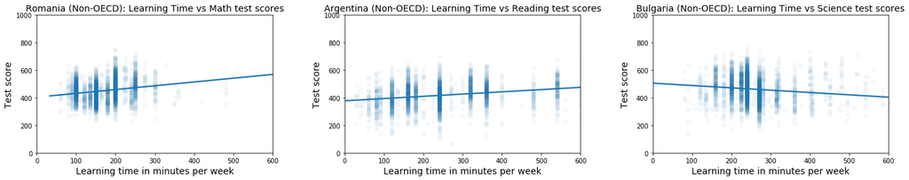

```python
plt.figure(figsize = [20, 4]);

plt.subplot(1,3,1)
sb.regplot(data=pisa_sub.query('CNT=="Romania" and MMINS<=600'), x='MMINS', y='PV1MATH', scatter_kws ={'alpha':1/30}, ci=None)
plt.title('Romania (Non-OECD): Learning Time vs Math test scores', fontsize=14)
plt.xlabel('Learning time in minutes per week', fontsize=14)
plt.ylabel('Test score', fontsize=14)
plt.ylim(0,1000)
plt.xlim(0,600)

plt.subplot(1,3,2)
sb.regplot(data=pisa_sub.query('CNT=="Argentina" and LMINS<=600'), x='LMINS', y='PV1READ', scatter_kws ={'alpha':1/30}, ci=None)
plt.title('Argentina (Non-OECD): Learning Time vs Reading test scores', fontsize=14)
plt.xlabel('Learning time in minutes per week', fontsize=14)
plt.ylabel('Test score', fontsize=14)
plt.ylim(0,1000)
plt.xlim(0,600)

plt.subplot(1,3,3)
sb.regplot(data=pisa_sub.query('CNT=="Bulgaria" and SMINS<=600'), x='SMINS', y='PV1SCIE', scatter_kws ={'alpha':1/30}, ci=None)
plt.title('Bulgaria (Non-OECD): Learning Time vs Science test scores', fontsize=14)
plt.xlabel('Learning time in minutes per week', fontsize=14)
plt.ylabel('Test score', fontsize=14)
plt.ylim(0,1000)
plt.xlim(0,600)

plt.tight_layout()
```